# First R Practical - Intro & Basics of Assignment, Arithmetic and Vectors

January 12, 2015

## Why Use R?

The simplest answer for why you should use R is that it’s the de facto standard statistical software in the social sciences. That means we all wind up benefiting from the collective wisdom of other researchers who are also using R. A relatively large community of support has also sprung up around R, meaning if you run into trouble with something in R, there is probably already a [StackOverflow](https://stackoverflow.com/questions/tagged/r) answer for it, and if there isn’t, someone will be able to provide you with the answer. There is also a lot of community investment in developing useful tools to use with R.

R is also free, so you don’t need to worry about institutional or student licenses to use it. You’ll be able to use the skills you learn in this course in any other research context after you leave Edinburgh, because you don’t have to worry about your student copy expiring. The popularity and use of R in the business world is on the rise as well.

But there’s more to R than “it’s free” and “everyone’s using it”. The biggest benefit to using R is that it allows us to do reproducible research. As long as you keep a record of the code you’ve run (and you will, in this course), you’ll be able to come back to the data at any later date and be able to precisely replicate what you did. This isn’t possible in, say, Excel, where there’s no way to programatically record everything that you clicked, and in what order. It also means that you can precisely communicate exactly the steps of your data analyses by sharing the code you used to run it.

For more on why to use R, [see this blog post](http://monkeysuncle.stanford.edu/?p=367).

### Getting Help

- Every R function has built in documentation that you can access with `?`
- The site StackOverflow is devoted to answering programming questions in general, and they have [a lot of questions and answers just for R](https://stackoverflow.com/questions/tagged/r).
- There are mailing lists just for R data manipulation [manipulatr list](https://groups.google.com/forum/#!forum/manipulatr), and for ggplot2 [ggplot2 list](https://groups.google.com/forum/#!forum/ggplot2)
- When in doubt, copy-paste any error you get into google (or search engine of your choice).

### Other Resources

- [My original R study group notes.](https://jofrhwld.github.io/rstudy/index.html)
- An interactive course, in the browser, for R http://tryr.codeschool.com/
- UCLA seems to [have some good materials](http://www.ats.ucla.edu/stat/r/).
- Keep an eye on [what RStudio puts together](http://www.rstudio.com/resources/training/online-learning/).

## R and RStudio

It’s important to keep distinct the features of R that are really part of R, and which parts are convenient things that RStudio does. One RStudio feature that I’d encourage you to utilize is its “projects”.

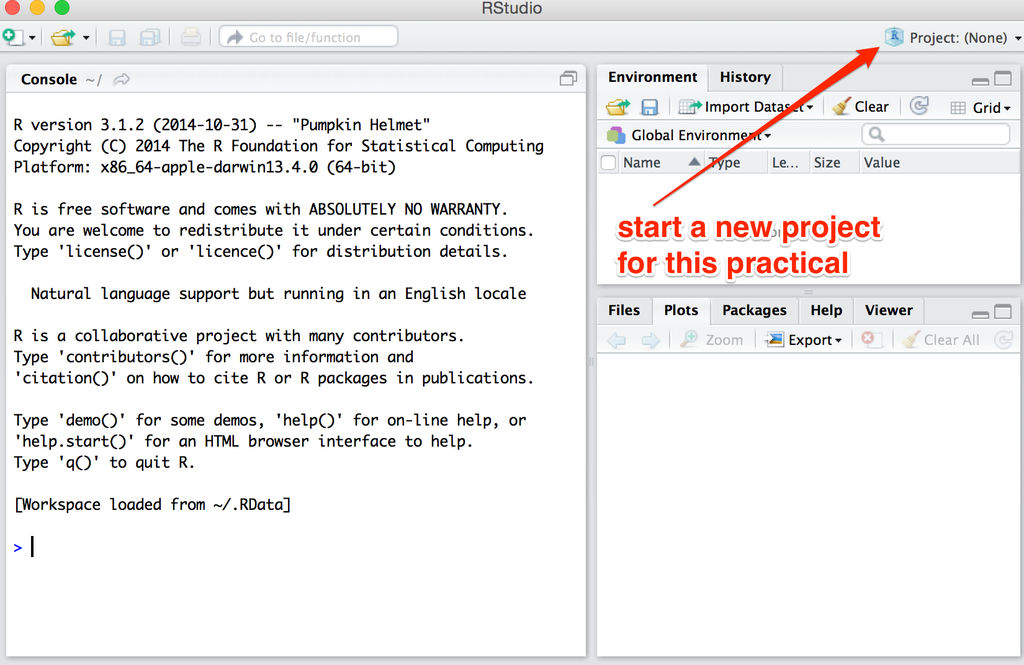

By setting up different RStudio projects for each of your data analysis needs, you’ll have better R Workspace Hygiene (more on that in a moment). You’ll probably want to have one project for the R practical exercises, and one for your final project.

## The course R Package

There are a lot of R packages that are maintained on CRAN, the official R package repository. It was CRAN that you were communicating with when you ran `install.packages()`. For the most part, any new package you hear about will be available on CRAN, and you can install it as simply as you did yesterday.

I’m also maintaining a special R package just for this course on Github. It’ll mostly contain sample data sets that we’ll work with in the practicals. We’ll probably begin most practicals by updating this package. Installing a package from Github involves one extra step of loading the `devtools` package, like so:

```r
  library("devtools")
```

Once you’ve loaded `devtools`, the function `install_github()` should be available. This is the code to install the `grammarOfVariationData` package:

```r
  install_github("jofrhwld/grammarOfVariationData")
```

To load the package we’ve just installed, the code is:

```r
  library("grammarOfVariationData")
```

## Basics: Assignment, Vectors, and Indexing

Select `File>New File>R Script` in the RStudio menu, and for the rest of the code snippits presented here, type them into the R script file.

One way to think about R is that it’s a calculator.

```r
3+3
```

```
## [1] 6
```

```r
2*4
```

```
## [1] 8
```

```r
(369-1)/6
```

```
## [1] 61.33333
```

### Assignment

You can assign **values** to **variables** using the assignment operator: `<-` or `->`.

```r
x <- 10
y <- 2*3
```

Once you’ve assigned a value to a variable, you can reuse the value stored in that variable for other purposes, like just printing it out again

```r
x
```

```
## [1] 10
```

```r
y
```

```
## [1] 6
```

Or by adding the two values together

```r
x + y
```

```
## [1] 16
```

Numerical values are just one kind of basic value that R can work with, the others include characters

```r
least_likely <- c("Berniementum", "hoverboard", "sitbit", "Uber for X")
```

And `TRUE`/`FALSE` values

```r
T
```

```
## [1] TRUE
```

As we work with more and more complex values (things like big data structures, or statistical models), we’ll be assigning them to variables in the same exact way.

#### Best Practices for Variable Names

I’d suggest following [Hadley Wickham’s R style guide](http://adv-r.had.co.nz/Style.html) when it comes to naming variables.

> Variable […] names should be lowercase. Use an underscore (_) to separate words within a name. Generally, variable names should be nouns […]. Strive for names that are concise and meaningful (this is not easy!).

This should be familiar to you from linguistics. It’s the tension between ease of articulation (or reducing the amount of typing you need to do), and being informative.

It gives these as examples of good and bad names:

```r
# Good
day_one
day_1

# Bad
first_day_of_the_month
DayOne
dayone
djm1
```

### Vectors

Vectors are essentially lists of data, and can contain characters, numbers, or TRUE FALSE values.[^1] There are a number of ways to create vectors in R, and frequently doing data manipulation will produce subvectors of data. The table below has some commands for creating vectors.

| Function | Description |
| --- | --- |
| `1:10` | This produces a vector of integers from 1 to 10.Reversing the order of the numbers will produce a vector of decreasing values |
| `c(...)` | This produces a vector of whatever is passed as an argument to `c()`. `e.g. c(1,2,3,4)` |
| `seq(from,to,...)` | This produces a sequence of numbers either by a given increment or evenly spaced to a given length. `seq(1,10,by=0.5)` `seq(1,10,length=11)` |
| `rep(x,...)` | This produces a vector of repetitions of x by a given number of times. `rep(1,6)` `rep(1:3,2)` `rep("hello world",4)` |

#### Vector Arithmetic

A pretty cool and unique feature of R is how you can do arithmetic with vectors. First, let’s create a vector called `test_vec` with the values 1, 5 and 8.

```r
test_vec <- c(1, 5, 8)
```

If you just want to add 1 to each of these numbers, it’s as simple as

```r
test_vec + 1
```

```
## [1] 2 6 9
```

Let’s say that the values in `test_vec` actually represent the number of responses to a survey question. Pollsters asked students if they enjoyed the taking The Grammar of Variation, and one said “No”, 5 said “Yes”, and 8 said “Not sure”. If we wanted to convert these counts into proportions, we could do so like this:

```r
#' Total number of responses
sum(test_vec)
```

```
## [1] 14
```

```r
#' Convert counts to proportions
test_vec/sum(test_vec)
```

```
## [1] 0.07142857 0.35714286 0.57142857
```

On top of being able to add one number to all of the elements in a vector, you can also add two vectors of the same lenght together elementwise. Let’s create two vectors called `alpha` and `beta`.

```r
alpha <- c(1,3,8)
beta <- c(5,2,10)
```

When you type in `alpha + beta`, R will add the first value in `alpha` to the first value in `beta`, the second value in `alpha` to the second value in `beta`, etc.

```r
alpha + beta
```

```
## [1]  6  5 18
```

```r
alpha * beta
```

```
## [1]  5  6 80
```

I wind up doing this kind of vector arithmetic alot. For example, here are two more vectors we’ll call `year_of_interview` and `age`. Let’s say they represent the ages of three different people, who were interviewed at three different points in time.

```r
year_of_interview <- c(1981, 1991, 2001)
age <- c(20, 55, 39)
```

If you want to know the dates of birth of these speakers, it’s just

```r
year_of_interview - age
```

```
## [1] 1961 1936 1962
```

And if you wanted to know how old these people would be today

```r
2015 - (year_of_interview - age)
```

```
## [1] 54 79 53
```

### Indexing

If you have a bunch of values stored in a vecor, and you want to pull out specific ones, you can do so by indexing it with square brackets `[]`.

#### Indexing by Position

Let’s start by indexing by position. R has some built in vectors for you to use, like one called `letters`. We haven’t defined `letters`, and it’s not listed as being in your R environment, but it’s there.

```r
letters
```

```
##  [1] "a" "b" "c" "d" "e" "f" "g" "h" "i" "j" "k" "l" "m" "n" "o" "p" "q"
## [18] "r" "s" "t" "u" "v" "w" "x" "y" "z"
```

The first value in a vector has index `1`, the second index `2`, and so on.[^2] If you’ve forgotten what the 19th letter of the alphabet is, you can find it out like so:

```r
letters[19]
```

```
## [1] "s"
```

If instead of just one number, you use another vector to index `letters`, you’ll get back out another vector.

```r
yes <- c(25, 5, 19)
letters[yes]
```

```
## [1] "y" "e" "s"
```

```r
abba <- c(1, 2, 2, 1)
letters[abba]
```

```
## [1] "a" "b" "b" "a"
```

#### Logical Indexing

You can also index by logical values. Let’s come back to our vector called `test_vec`

```r
test_vec
```

```
## [1] 1 5 8
```

If we make another vector of `TRUE` and `FALSE` values of the same length, we can use it to index `test_vec`.

```r
logical_vec <- c(T, F, T)
test_vec[logical_vec]
```

```
## [1] 1 8
```

You only get back values where the index vector was `TRUE`.

Of course, what you’ll usually do is generate a vectore of `TRUE` and `FALSE` values by using a logical operator.

```r
test_vec > 2
```

```
## [1] FALSE  TRUE  TRUE
```

```r
test_vec[test_vec > 2]
```

```
## [1] 5 8
```

## Logical Operators

The following operators will return a vector of `TRUE` and `FALSE` values.

| Operator | Meaning |
| --- | --- |
| `==` | exactly equal to |
| `!=` | not equal to |
| `>` | greater than |
| `<` | less than |
| `>=` | greater than or equal to |
| `<` | less than |
| `<=` | less than or equal to |

You can compare two vectors this way too.

```r
alpha
```

```
## [1] 1 3 8
```

```r
beta
```

```
## [1]  5  2 10
```

```r
#' elementwise comparison
alpha < beta
```

```
## [1]  TRUE FALSE  TRUE
```

There are three more operators that have an effect on `TRUE` and `FALSE` vectors.

| Operator | Meaning |
| --- | --- |
| `!` | not x changes all `T` to `F` and `F` to `T` |
| `\|` | x or y |
| `&` | x and y |

```r
x <- c(T, T, F, F)
y <- c(T, F, T, F)
```

```r
cbind(
  x = x,
  y = y,
  and = x&y,
  or = x|y
)
```

```
##          x     y   and    or
## [1,]  TRUE  TRUE  TRUE  TRUE
## [2,]  TRUE FALSE FALSE  TRUE
## [3,] FALSE  TRUE FALSE  TRUE
## [4,] FALSE FALSE FALSE FALSE
```

[^1]: But not with mixed types.
[^2]: This makes R different from many other programming languages, where indexing starts with `0`.

~